# Parte Individual Trabajo Data Science

Jairo González Hernández

# Students Performance Factors

**Trabajo Final Data Science**

*Master en Ingeniería del Software: Cloud, Datos y Gestión de TI*

#PREGUNTA 1. ¿Los factores institucionales influyen en el rendimiento académico de los estudiantes?

A menudo, los padres tienden a atribuir el rendimiento académico de sus hijos exclusivamente al esfuerzo y dedicación individual. No obstante, el **entorno escolar y los factores institucionales** juegan un papel igualmente crucial en la obtención de buenos resultados académicos. Diversos estudios han demostrado que los factores institucionales tienen un impacto considerable en el desempeño de los estudiantes. Por ejemplo, estudios como los de **Hattie (2009)**, sugieren que la calidad del profesorado es uno de los factores con mayor impacto en el rendimiento académico de los estudiantes. Además, **Bashir & Liu (2016)** evidencian cómo el tipo de escuela, ya sea pública o privada, puede influir en los resultados académicos debido a diferencias en infraestructura, recursos y metodologías de enseñanza.

Por tanto,elementos como la *calidad del profesorado*, el *tipo de institución educativa* y *el ambite en las clases* pueden influir de manera significativa en el proceso de aprendizaje y en el rendimiento académico de los estudiantes.

Para comprender mejor la relación entre estos factores y el rendimiento académico, es esencial llevar a cabo análisis estadísticos que permitan identificar correlaciones o diferencias significativas. Esto puede proporcionar información valiosa sobre cómo optimizar las condiciones institucionales para mejorar los resultados educativos.

Este estudio tiene como objetivo analizar **el impacto de los factores institucionales en el rendimiento académico**, evaluando en qué medida estos elementos afectan las calificaciones de los estudiantes. De este modo, los hallazgos obtenidos podrían contribuir a la mejora de las políticas educativas, la optimización de recursos en las instituciones escolares y el desarrollo de estrategias que reduzcan desigualdades en el aprendizaje. Comprender estas dinámicas permitirá identificar oportunidades para fortalecer el sistema educativo y promover un acceso más equitativo a una educación de calidad.

A continuación, se muestran una serie de preguntas que se pueden llegar a responder con este pequeño estudio:

- **¿Qué factor institucional tiene mayor impacto en el exámen final?**
- **¿Las escuelas públicas y privadas muestran diferencias significativas?**

## Librerías

La función ipak está diseñada para facilitar la instalación y carga de paquetes en R. Es útil cuando desea asegurarse de que todos los paquetes necesarios para un script o proyecto se instalan y cargan automáticamente. https://gist.github.com/stevenworthington/3178163

```r
ipak <- function(pkg){
  new.pkg <- pkg[!(pkg %in% installed.packages()[, "Package"])]
  if(length(new.pkg))
    install.packages(new.pkg, dependencies = TRUE)
  sapply(pkg, require, character.only = TRUE)
}

packages <- c("tidyverse","ggplot2", "dplyr","gridExtra", "reshape2", "igraph", "car", "ggridges", "factoextra", "cluster", "NbClust", "RColorBrewer","caret", "gbm", "arules", "arulesViz")

ipak(packages)
```

```
   tidyverse      ggplot2        dplyr    gridExtra     reshape2       igraph          car
        TRUE         TRUE         TRUE         TRUE         TRUE         TRUE         TRUE
    ggridges   factoextra      cluster      NbClust RColorBrewer        caret          gbm
        TRUE         TRUE         TRUE         TRUE         TRUE         TRUE         TRUE
      arules    arulesViz
        TRUE         TRUE
```

## Lectura de los datos

El punto de partida para este estudio será el conjunto de datos almacenado en **“df_cleaned.csv”**, un **archivo CSV** que contiene el dataframe global completamente preprocesado. En este conjunto de datos, se han llevado a cabo diversas tareas de limpieza, incluyendo la eliminación de filas con valores nulos o faltantes, el tratamiento de valores atípicos, la codificación de variables categóricas y la escalado de variables temporales.

El proceso completo de preprocesamiento de datos está documentado en el Notebook `global.Rmd`.

Cargamos el dataset desde el **archivo CSV** y verificamos su correcta importación:

```r
data <- read.csv("data/df_cleaned.csv", header=TRUE)
head(data)
```

|  | Previous_Scores | Previous_Scores_Category | Hours_Studied | Attendance | Parental_Involvement | Access_to_Resources | Extracurricular_Activities | Sleep_Hours | Motivation_Level | Internet_Access | Tutoring_Sessions | Family_Income | Teacher_Quality | Peer_Influence | Physical_Activity | Learning_Disabilities | Parental_Education_Level | Distance_from_Home | Exam_Score | School_Type_Private | School_Type_Public | Gender_Male | Gender_Female |
| --- | --- | --- | --- | --- | --- | --- | --- | --- | --- | --- | --- | --- | --- | --- | --- | --- | --- | --- | --- | --- | --- | --- | --- |
| 1 | 73 | 2 | 23 | 84 | 1 | 3 | 0 | 7 | 1 | 1 | 0 | 1 | 2 | 3 | 3 | 0 | 1 | 1 | 67 | 0 | 1 | 1 | 0 |
| 2 | 59 | 1 | 19 | 64 | 1 | 2 | 0 | 8 | 1 | 1 | 2 | 2 | 2 | 1 | 4 | 0 | 2 | 2 | 61 | 0 | 1 | 0 | 1 |
| 3 | 91 | 4 | 24 | 98 | 2 | 2 | 1 | 7 | 2 | 1 | 2 | 2 | 2 | 2 | 4 | 0 | 3 | 1 | 74 | 0 | 1 | 1 | 0 |
| 4 | 98 | 4 | 29 | 89 | 1 | 2 | 1 | 8 | 2 | 1 | 1 | 2 | 2 | 1 | 4 | 0 | 1 | 2 | 71 | 0 | 1 | 1 | 0 |
| 5 | 65 | 1 | 19 | 92 | 2 | 2 | 1 | 6 | 2 | 1 | 3 | 2 | 3 | 2 | 4 | 0 | 2 | 1 | 70 | 0 | 1 | 0 | 1 |
| 6 | 89 | 3 | 19 | 88 | 2 | 2 | 1 | 8 | 2 | 1 | 3 | 2 | 2 | 3 | 3 | 0 | 3 | 1 | 71 | 0 | 1 | 1 | 0 |

```r
dim(data)
```

```
[1] 6378   23
```

Vamos a examinar la estructura del conjunto de datos para obtener un resumen de las variables presentes, su tipo de dato y una visión general de cómo están organizados los datos.

```r
str(data)
```

```
'data.frame':   6378 obs. of  23 variables:
 $ Previous_Scores           : int  73 59 91 98 65 89 68 50 80 71 ...
 $ Previous_Scores_Category  : int  2 1 4 4 1 3 1 1 3 2 ...
 $ Hours_Studied             : int  23 19 24 29 19 19 29 25 17 23 ...
 $ Attendance                : int  84 64 98 89 92 88 84 78 94 98 ...
 $ Parental_Involvement      : int  1 1 2 1 2 2 2 1 2 2 ...
 $ Access_to_Resources       : int  3 2 2 2 2 2 1 3 3 2 ...
 $ Extracurricular_Activities: int  0 0 1 1 1 1 1 1 0 1 ...
 $ Sleep_Hours               : int  7 8 7 8 6 8 7 6 6 8 ...
 $ Motivation_Level          : int  1 1 2 2 2 2 1 2 3 2 ...
 $ Internet_Access           : int  1 1 1 1 1 1 1 1 1 1 ...
 $ Tutoring_Sessions         : int  0 2 2 1 3 3 1 1 0 0 ...
 $ Family_Income             : int  1 2 2 2 2 2 1 3 2 3 ...
 $ Teacher_Quality           : int  2 2 2 2 3 2 2 3 1 3 ...
 $ Peer_Influence            : int  3 1 2 1 2 3 2 1 2 3 ...
 $ Physical_Activity         : int  3 4 4 4 4 3 2 2 1 5 ...
 $ Learning_Disabilities     : int  0 0 0 0 0 0 0 0 0 0 ...
 $ Parental_Education_Level  : int  1 2 3 1 2 3 1 1 2 1 ...
 $ Distance_from_Home        : int  1 2 1 2 1 1 2 3 1 2 ...
 $ Exam_Score                : int  67 61 74 71 70 71 67 66 69 72 ...
 $ School_Type_Private       : int  0 0 0 0 0 0 1 0 1 0 ...
 $ School_Type_Public        : int  1 1 1 1 1 1 0 1 0 1 ...
 $ Gender_Male               : int  1 0 1 1 0 1 1 1 1 1 ...
 $ Gender_Female             : int  0 1 0 0 1 0 0 0 0 0 ...
```

El conjunto de datos preprocesado df_cleaned está compuesto por **6,378 filas y 23 columnas**. Como podemos observar, dichas variables han sido convertidas a **valores enteros** y ya han sido transformadas mediante el proceso de **One-Hot Encoding** para convertir variables categóricas en variables numéricas binarias.

## Plan para el Análisis y Predicción del Rendimiento Académico Basado en Factores Institucionales

El objetivo de este estudio es examinar **cómo los factores institucionales influyen en el rendimiento académico** de los estudiantes y utilizar esta información para predecir su calificación final (`Exam_Score`). Para ello, el análisis se desarrollará en dos etapas principales:

1. **Análisis Exploratorio de Datos (EDA)**

En esta fase se explorarán los datos para identificar patrones y relaciones entre los factores institucionales y el rendimiento académico. Aunque el objetivo es predecir el valor de la variable `Exam_Score` haciendo uso de variables correspondientes a factores institucionales se realizará un análisis exploratorio para observar cómo estos factores pueden afectar otras variables académicas, como la asistencia, horas de estudio, entre otros. El objetivo de este análisis es identificar posibles correlaciones entre estos factores y obtener una visión preliminar sobre cómo podrían influir en el rendimiento académico. Este enfoque servirá como base para futuros estudios más profundos.

2. **Modelado Predictivo del Rendimiento Académico**

Una vez comprendidas las relaciones entre los factores institucionales y el desempeño estudiantil, se implementará un modelo de predicción para estimar la calificación final de los alumnos en función de estas variables, con el objetivo de observar qué tan bien los factores institucionales pueden explicar el rendimiento académico. Este modelo permitirá identificar patrones y relaciones clave, así como predecir el rendimiento futuro de los estudiantes en función de las características del entorno escolar.

## Preprocesamiento de los datos

El primer paso es identificar las variables del conjunto de datos que representan factores institucionales, aquellos que dependen de la infraestructura educativa, el entorno escolar y los recursos disponibles. Para este estudio, se seleccionaron las siguientes variables clave:

### Elección de Factores Institucionales

El primer paso en este análisis es identificar las variables dentro del conjunto de datos que representan **factores institucionales**. Estos factores son aquellos que están directamente relacionados con la **infraestructura educativa**, el **entorno escolar** y los recursos disponibles dentro de la institución. En resumen, estos factores abarcan todas aquellas condiciones dependientes del centro que influyen en el aprendizaje de los estudiantes.

Para este estudio, se seleccionaron las siguientes variables clave, las cuales han sido consideradas fundamentales para evaluar el impacto de los factores institucionales en el rendimiento académico de los estudiantes:

- **Teacher Quality (Calidad de los profesores)**: La calidad de los profesores es uno de los factores más determinantes en el éxito académico. Los profesores con una formación sólida y habilidades pedagógicas adecuadas tienen la capacidad de enseñar de manera más efectiva, lo que se traduce en mejores resultados para los estudiantes. Por lo tanto, esta variable es esencial para evaluar cómo la calidad educativa influye en el desempeño de los alumnos.
- **School_Type_Private / School_Type_Public (Tipo de escuela)**: El tipo de escuela, ya sea pública o privada, es otra variable crucial. La diferencia entre escuelas públicas y privadas puede afectar el rendimiento debido a la variación en financiamiento, acceso a materiales, métodos de enseñanza, etc.
- **Peer_Influence (Influencia de compañeros)**: Aunque no es un factor institucional directo, la influencia de los compañeros está relacionada con el ambiente social y académico dentro de la escuela. Un entorno positivo, donde los compañeros fomentan hábitos de estudio y motivación, puede ser un factor que mejore el rendimiento de los estudiantes. Por el contrario, un ambiente negativo, en el que los compañeros influyan de manera perjudicial, podría desmotivar a los estudiantes y afectar su rendimiento.

**NOTA**: En cuanto a `Peer_Influence`, aunque no se considera un factor estrictamente institucional, hemos optado por incluirlo en el estudio con el fin de enriquecer el análisis y obtener una perspectiva más integral de los elementos que impactan el rendimiento académico.

```r
institucional_columns <- c("Teacher_Quality", "School_Type_Private",  "Peer_Influence")
```

### Elección de Factores académicos

Como se mencionó anteriormente, aunque los modelos predictivos se centren exclusivamente en la calificación final del examen del estudiante, se llevará a cabo un análisis exploratorio para examinar cómo los factores institucionales se relacionan con diversas variables académicas. Para ello, debemos quedarnos con aquellas variables que reflejan de manera más directa los factores educativos que podrían tener un impacto en el desempeño de los estudiantes. En este caso nos vamos a quedar con:

-**Hours_Studied (Horas estudiadas)**: Esta variable refleja la cantidad de tiempo que el estudiante dedica a estudiar fuera del aula. Es un factor académico clave, ya que un mayor número de horas de estudio suele estar asociado con un mejor dominio de los contenidos y una preparación más sólida para los exámenes.

- **Attendance (Asistencia)**: La asistencia a clase es una medida fundamental del compromiso del estudiante con su aprendizaje.
- **Motivation_Level (Motivación del estudiante)**: La motivación influye directamente en la dedicación y esfuerzo que el estudiante pone en sus estudios por lo que también es un factor académico clave.

-**Previous_Scores (Calificaciones previas)**: Las calificaciones suponen el pilar clave en el rendimiento académico. Además,los estudiantes que han obtenido buenos resultados en el pasado suelen mantener un rendimiento alto en el futuro por lo que las calificaciones previas son un factor clave.

- **Exam_Score**: Es la variable dependiente principal que se quiere analizar, ya que representa la calificación final del examen, que es un reflejo directo del rendimiento académico.

```r
academic_columns <- c("Hours_Studied", "Attendance", "Motivation_Level", "Previous_Scores", "Exam_Score")
```

A continuación, eliminamos del dataframe las columnas restantes, ya que no son relevantes para el objetivo de nuestro estudio.

```r
relevant_columns <- c(institucional_columns, academic_columns)
# Crear un nuevo dataframe con solo las variables relevantes
df_cleaned <- data[, relevant_columns]
str(df_cleaned)
```

```
'data.frame':   6378 obs. of  8 variables:
 $ Teacher_Quality    : int  2 2 2 2 3 2 2 3 1 3 ...
 $ School_Type_Private: int  0 0 0 0 0 0 1 0 1 0 ...
 $ Peer_Influence     : int  3 1 2 1 2 3 2 1 2 3 ...
 $ Hours_Studied      : int  23 19 24 29 19 19 29 25 17 23 ...
 $ Attendance         : int  84 64 98 89 92 88 84 78 94 98 ...
 $ Motivation_Level   : int  1 1 2 2 2 2 1 2 3 2 ...
 $ Previous_Scores    : int  73 59 91 98 65 89 68 50 80 71 ...
 $ Exam_Score         : int  67 61 74 71 70 71 67 66 69 72 ...
```

Finalmente, nuestro conjunto de datos con el que trabajaremos en este estudio constará de **6378 filas** y **8 columnas**. Las variables con las que nos quedamos son las siguientes:

Factores institucionales:

- **Teacher_Quality**: Calidad de los profesores (1: Baja, 2: Media, 3: Alta).
- **School_Type_Private**: Indica si la escuela es privada (0: No, 1: Sí).
- **Peer_Influence**: Influencia de los compañeros en el rendimiento académico (1: Negativa, 2: Neutra, 3: Positiva).

Factores académicos:

- **Hours_Studied**: Número de horas de estudio semanales.
- **Attendance**: Porcentaje de asistencia a clases.
- **Motivation_Level**: Nivel de motivación del estudiante (1: Bajo, 2: Medio, 3: Alto).
- **Previous_Scores**: Calificaciones obtenidas en exámenes anteriores.
- **Exam_Score**: Calificación del examen final (variable dependiente).

### Categorización de variables

En este proceso, vamos a recategorizar algunas columnas, ya que al importar `df_cleaned`, todas las variables estaban en formato numérico, incluso las que en el dataset original eran categóricas por lo que es necesario discretizar estas variables para convertirlas en categorías, lo que nos permitirá visualizarlas de manera más clara y comprensible.

**NOTA**: La categorización se realiza con el fin de mejorar la visualización de gráficas que muestran relaciones o distribuciones de variables categóricas, facilitando su interpretación.

```r
recategorize_variable <- function(data, var_name, new_labels) {
  if (!var_name %in% names(data)) {
    stop(paste("La variable", var_name, "no existe en el dataframe."))
  }

  # Convertimos la variable en un factor con los nuevos niveles
  data[[var_name]] <- factor(data[[var_name]], labels = new_labels)

  return(data)
}
```

```r
df_recategorize <- recategorize_variable(df_cleaned, "Motivation_Level", c("Low", "Medium", "High"))
df_recategorize <- recategorize_variable(df_recategorize, "Teacher_Quality", c("Low", "Medium", "High"))
df_recategorize <- recategorize_variable(df_recategorize, "Peer_Influence", c("Negative", "Neutral", "Positive"))
df_recategorize$School_Type_Private <- factor(df_recategorize$School_Type_Private, levels = c(0, 1), labels = c("No", "Yes"))

head(df_recategorize)
```

|  | Teacher_Quality | School_Type_Private | Peer_Influence | Hours_Studied | Attendance | Motivation_Level | Previous_Scores | Exam_Score |
| --- | --- | --- | --- | --- | --- | --- | --- | --- |
| 1 | Medium | No | Positive | 23 | 84 | Low | 73 | 67 |
| 2 | Medium | No | Negative | 19 | 64 | Low | 59 | 61 |
| 3 | Medium | No | Neutral | 24 | 98 | Medium | 91 | 74 |
| 4 | Medium | No | Negative | 29 | 89 | Medium | 98 | 71 |
| 5 | High | No | Neutral | 19 | 92 | Medium | 65 | 70 |
| 6 | Medium | No | Positive | 19 | 88 | Medium | 89 | 71 |

### Escalado de variables

Por último, debido a que vamos a estudiar la correlación entre las variables, es importante normalizarlas previamente. Esto garantiza que las diferencias en escalas no afecten la interpretación de los resultados.

Por ejemplo, la calificación final del examen (`Exam_Score`) suele oscilar entre **60 y 100**, mientras que el número de horas de estudio (`Hours_Studied`) puede encontrarse en un rango completamente distinto. A su vez, la variable `Attendance`, que mide el porcentaje de asistencia, se expresa en valores de 0 a 100. Estas diferencias en magnitud **pueden influir en el cálculo de correlaciones y en la interpretación de los modelos predictivos** de modo que se generen sesgos en el análisis.

De esta forma, los patrones y relaciones identificados en los datos no estarán sesgados por diferencias en la escala de las variables. Además, muchos algoritmos de machine learning, como la regresión logística, convergen más rápido y de manera más estable cuando las variables están normalizadas. Esto mejora el rendimiento del modelo y ayuda a obtener predicciones más precisas.

```r
df_scaled <- df_cleaned
df_scaled[sapply(df_cleaned, is.numeric)] <- scale(df_cleaned[sapply(df_cleaned, is.numeric)])

# Convertir a tibble
df_scaled <- as_tibble(df_scaled)
```

Almacenamos las variables escaladas en `df_scaled`.

```r
head(df_scaled)
```

| Teacher_Quality | School_Type_Private | Peer_Influence | Hours_Studied | Attendance | Motivation_Level | Previous_Scores | Exam_Score |
| --- | --- | --- | --- | --- | --- | --- | --- |
| -0.3281521 | -0.6620888 | 1.0685529 | 0.5050391 | 0.3444933 | -1.3050005 | -0.1434798 | -0.06439236 |
| -0.3281521 | -0.6620888 | -1.5755713 | -0.1632471 | -1.3870000 | -1.3050005 | -1.1156758 | -1.59778808 |
| -0.3281521 | -0.6620888 | -0.2535092 | 0.6721107 | 1.5565387 | 0.1322803 | 1.1064865 | 1.72456931 |
| -0.3281521 | -0.6620888 | -1.5755713 | 1.5074684 | 0.7773667 | 0.1322803 | 1.5925845 | 0.95787145 |
| 1.3355635 | -0.6620888 | -0.2535092 | -0.1632471 | 1.0370907 | 0.1322803 | -0.6990204 | 0.70230550 |
| -0.3281521 | -0.6620888 | 1.0685529 | -0.1632471 | 0.6907920 | 0.1322803 | 0.9676013 | 0.95787145 |

## 1. Análisis exploratorio de los datos (EDA)

### Distribuciones de Factores académicos

En este apartado, estudiaremos como se distribuyen los factores académicos. Lo primero, para las variables numéricas Generamos histogramas y gráficos de densidad para cada una de las variables numéricas, como `Hours_Studied`, `Attendance`, `Exam_Score` y `Previous_Scores`.

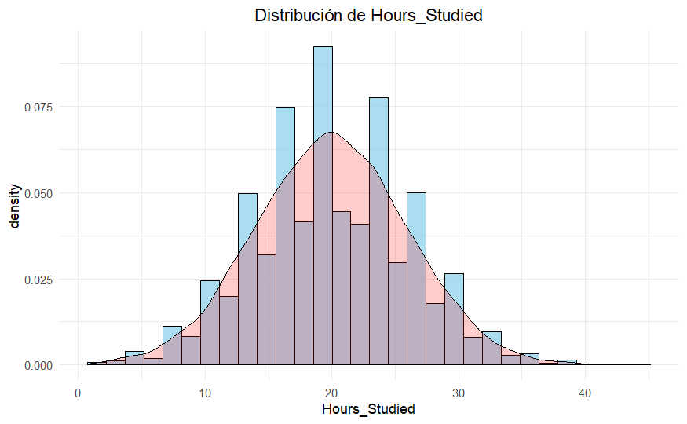

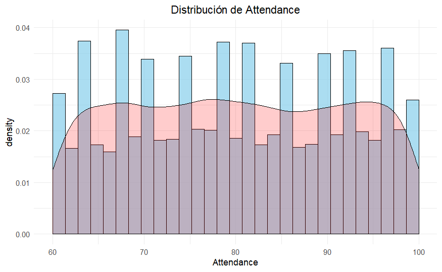

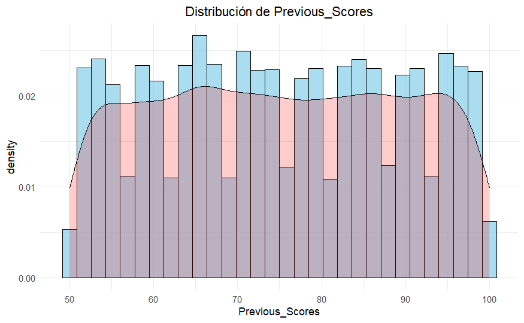

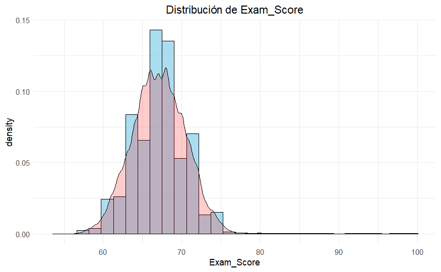

```r
plot_histogram_density <- function(data, numeric_vars) {
  for (var in numeric_vars) {
    if (!is.numeric(data[[var]])) {
      stop(paste("La variable", var, "no es numérica."))
    }
  }

  for (var in numeric_vars) {
    plot <- ggplot(data, aes_string(x = var)) +
      geom_histogram(aes(y = after_stat(density)), bins = 30, fill = "skyblue", color = "black", alpha = 0.7) +
      geom_density(alpha = 0.2, fill = "red") +
      ggtitle(paste("Distribución de", var)) +
      theme_minimal() +
      theme(plot.title = element_text(hjust = 0.5))

    print(plot)
  }
}

numeric_vars <- c("Hours_Studied", "Attendance", "Previous_Scores", "Exam_Score")
plot_histogram_density(df_recategorize, numeric_vars)
```

### Relaciones entre variables

En este apartado, exploraremos cómo las variables que conforman los factores institucionales influyen en la calificación final obtenida por los estudiantes. Estos factores incluyen variables como la calidad docente (`Teacher_Quality`), si es escuela privada (`School_Type_Private`) y la influencia de los compañeros (`Peer_Influence`). Con esto queremos apoyar la hipótesis central de estos factores podrían tener un impacto directo en el rendimiento académico, reflejado en las calificaciones finales de los estudiantes.

Para abordar esta cuestión, utilizaremos **gráficos de violín (violin_plots)** para estudiar la relación de los factores institucionales respecto a la asistencia de los alumnos (`attendance`) ya que estos permiten representar la distribución y densidad de los datos lo que nos facilitará visualizar la distribución de la asistencia de los alumnos en función de diferentes categorías dentro de las variables que representan los factores institucionales.

```r
violin_plot <- function(data, x_var, y_var) {
  # Asegúrate de que las variables existen en el dataframe
  if (!(x_var %in% names(data))) {
    stop(paste("La variable", x_var, "no existe en el dataframe."))
  }
  if (!(y_var %in% names(data))) {
    stop(paste("La variable", y_var, "no existe en el dataframe."))
  }

  # Crear el violin plot
  plot <- ggplot(data, aes_string(x = x_var, y = y_var, fill = x_var)) +
    geom_violin(trim = FALSE) +
    ggtitle(paste("Relación entre", x_var, "y", y_var)) +
    theme_minimal() +
    theme(plot.title = element_text(hjust = 0.5))

  # Mostrar el gráfico
  print(plot)
}
```

Tambien haremos uso de **gráfico de densidad superpuesto (density plot overlapped)** para estudiar la relación de los factores institucionales respecto a las calificaciones de los alumnos, tanto `previous_Scores` como `Exam_Scores`. La superposición de densidades nos va a facilitar la comparación visual entre las diferentes categorías de las variables, ayudándonos a entender si los estudiantes en diferentes contextos (por ejemplo, escuelas privadas versus públicas) tienen patrones de calificación diferentes.

```r
density_plot_overlapped <- function(df, numeric_variable, categorical_variable) {
  ggplot(df, aes_string(x = numeric_variable, fill = categorical_variable)) +
    geom_density(alpha = 0.5) +
    labs(title = paste("Distribución de ", numeric_variable, " respecto ", categorical_variable),
         x = numeric_variable,
         y = "Density",
         fill = categorical_variable) +
    theme_minimal()
}
```

Para estudiar la relacion de los factores institucionales respecto a las horas empleadas al estudio por cada estudiante (`hours_Studied`) vamos a hacer uso de **gráficos de caja (Boxplots)** ya que este tipo de gráfico permite ver la mediana, los cuartiles, y los valores atípicos, lo que nos ayuda a entender cómo varía el tiempo de estudio entre los distintos grupos. Además, destacan las diferencias de dispersión y posibles outliers, facilitando la comparación de cómo los estudiantes en distintos contextos manejan sus horas de estudio.

```r
boxplot_hours <- function(df, cat_var) {

  color_palette <- brewer.pal(min(length(unique(df[[cat_var]])), 9), "Pastel1")
  p <- ggplot(df, aes_string(x = cat_var, y = "Hours_Studied", fill = cat_var)) +
    geom_boxplot(outlier.colour = "red", outlier.shape = 16, outlier.size = 2) +  # Boxplot con outliers resaltados
    scale_fill_manual(values = color_palette) +
    theme_minimal() +
    labs(title = paste("Distribución de Horas Estudiadas por", gsub("_", " ", cat_var)),
         x = gsub("_", " ", cat_var),
         y = "Horas Estudiadas") +
    theme(plot.title = element_text(hjust = 0.5))  # Centrar el título

  # Mostrar el gráfico
  print(p)
}
```

Por último, para estudiar la relación entre los niveles de motivación de los alumnos y los factores institucionales se va a hacer uso de **Barras agrupadas con facetas** debido a que este tipo de gráfico permite comparar fácilmente la distribución de los niveles de motivación dentro de cada categoría del factor institucional. Las facetas dividen el gráfico por cada grupo del factor, lo que falicita la comparación entre categorías, mientras que las barras agrupadas muestran todas las proporciones de motivación de manera que también sean faciles de comparar.

```r
grouped_bar_plot_with_facets <- function(data, categoric_var) {
  data[[categoric_var]] <- as.factor(data[[categoric_var]])
  data$Motivation_Level <- as.factor(data$Motivation_Level)

  ggplot(data, aes(x = Motivation_Level, fill = Motivation_Level)) +
    geom_bar(position = "dodge", color = "black") +
    facet_wrap(~ get(categoric_var), scales = "free_y") +
    labs(
      title = paste("Distribución de Motivation_Level según", categoric_var),
      x = "Nivel de Motivación",
      y = "Cantidad de Estudiantes"
    ) +
    theme_minimal() +
    theme(
      strip.text = element_text(size = 12, face = "bold"),
      legend.position = "none"
    ) +
    scale_fill_brewer(palette = "Set3")
}
```

#### Relación entre Asistencia y factores Institucionales

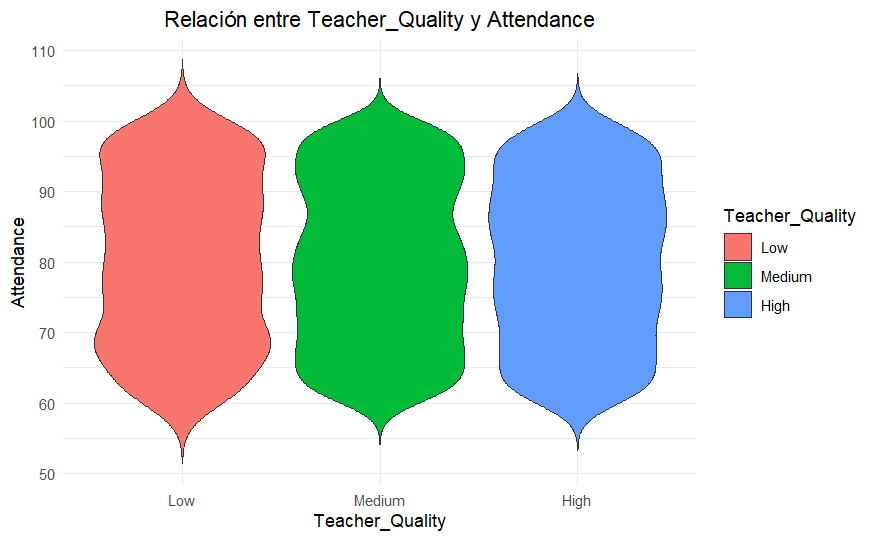

```r
violin_plot(df_recategorize, "Teacher_Quality", "Attendance")
```

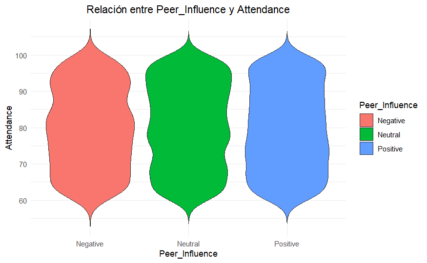

```r
violin_plot(df_recategorize, "Peer_Influence", "Attendance")
```

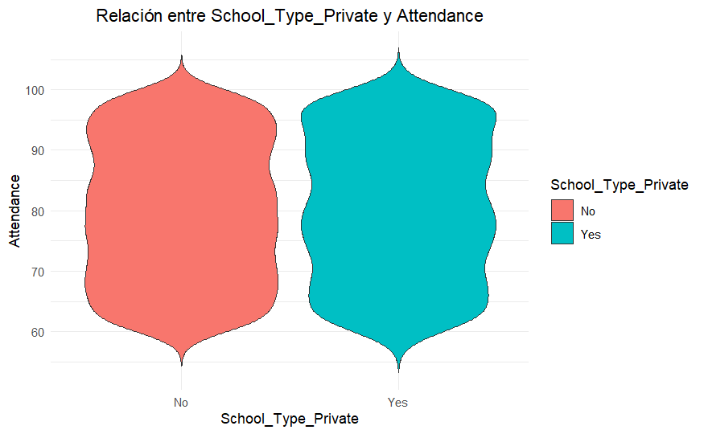

```r
violin_plot(df_recategorize, "School_Type_Private", "Attendance")
```

Podemos observar como no visualizamos grandes cambios respecto a las diferentes categorias dentro de cada una de las variables. Esto ya lo habiamos observado en el análisis exploratorio global realizado en el trabajo grupal. Sin embargo, la visualización mediante **violin plots** nos permite ver ver aspectos que podrían haber pasado desapercibidos en el análisis previo. A continuación, se describen los detalles más relevantes observados en cada uno de los factores institucionales analizados:

Respecto a **School_Type_Private**, los gráficos para las escuelas privadas (Private) y públicas (Public) muestran *distribuciones muy similares*, lo que indica que no hay una diferencia clara en el porcentaje de asistencia entre ambos grupos. Aunque podría esperarse que los estudiantes en escuelas privadas tengan una mayor asistencia debido a la percepción de una educación más exigente, los datos revelan que las distribuciones de asistencia en ambos tipos de escuela son casi idénticas. Esto sugiere que, en este caso específico, el tipo de escuela no tiene un impacto notable ni consistente sobre la asistencia de los estudiantes, *desafiando la idea de que las escuelas privadas tendrían una mayor tasa de asistencia debido a su supuesta mayor rigurosidad*.

Por último, en **teacher_quality** se observan *algunas diferencias en la distribución de la asistencia según la calidad del profesor*. Para los profesores de **alta calidad**, la densidad de los datos es mayor en los extremos, es decir, en los altos porcentajes de asistencia, lo que sugiere que *hay más estudiantes con asistencia muy alta en este grupo*. En cambio, para los profesores de **baja calidad**, la mayor densidad se concentra en los porcentajes más bajos de asistencia, lo que indica que los estudiantes *tienden a asistir menos a las clases*. En cuanto a los profesores de **calidad media**, su gráfico tiene más ondulaciones, lo que refleja una *mayor variabilidad en los porcentajes de asistencia*. Sin embargo, es importante destacar que, aunque existen estas pequeñas diferencias, los tres gráficos son bastante similares, lo que sugiere que el impacto de la calidad del profesor sobre la asistencia no es tan significativo o claro como podría esperarse.

#### Relación entre calificaciones y factores Institucionales

En este apartado vamos a estudiar tanto calificaciones previas (`Previous_Scores`) como las calificaciones en el exámen final (`Exam_Score`).

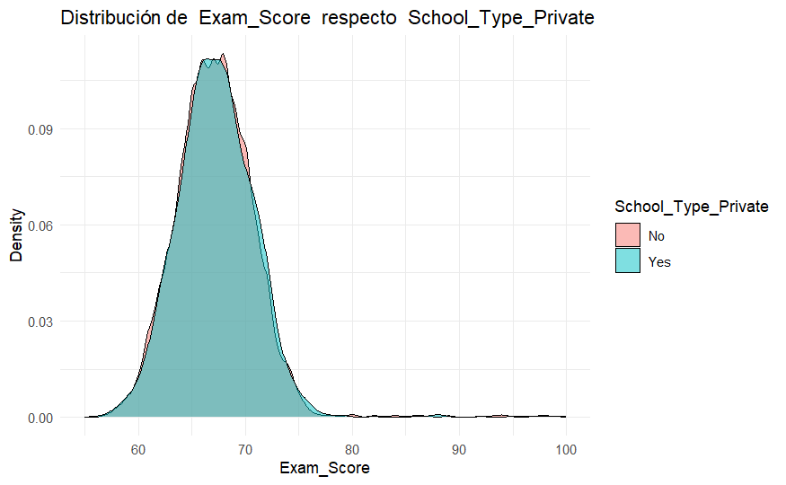

```r
density_plot_overlapped(df_recategorize, "Exam_Score", "School_Type_Private")
```

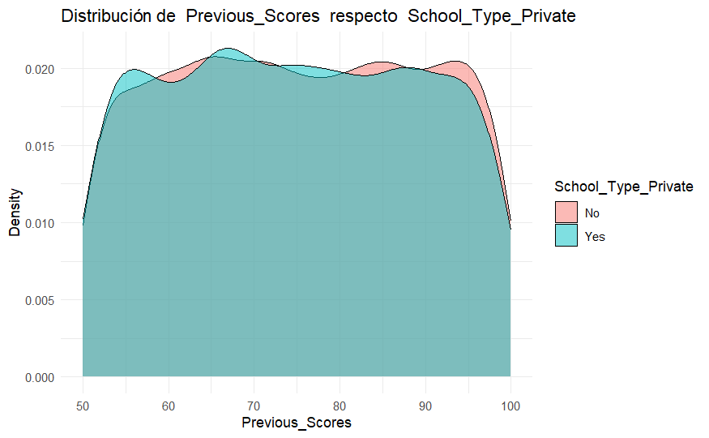

```r
density_plot_overlapped(df_recategorize, "Previous_Scores", "School_Type_Private")
```

Respecto a **School_Type_Private**, observamos que los gráficos de densidad para ambas variables son prácticamente idénticos, sin diferencias significativas. Sin embargo, un detalle a destacar es que, en cuanto a las **previous_Scores**, las escuelas públicas presentan una ligera mayor proporción de estudiantes con calificaciones superiores a 9 en comparación con las escuelas privadas.

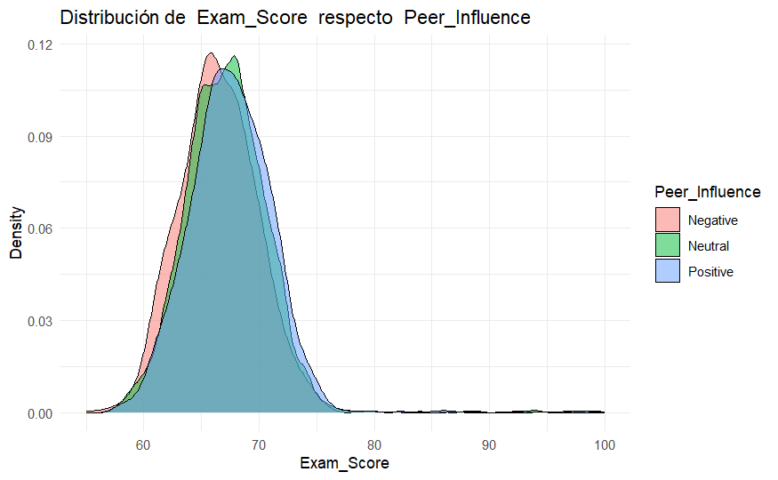

```r
density_plot_overlapped(df_recategorize, "Exam_Score", "Peer_Influence")
```

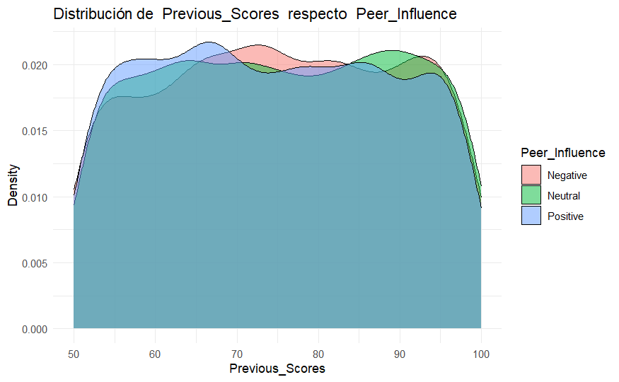

```r
density_plot_overlapped(df_recategorize, "Previous_Scores", "Peer_Influence")
```

Respecto a **Peer_Influence**, en `Exam_Score` se observa que una mala influencia de compañeros **(Negative)** tiene un *impacto negativo en las calificaciones*, ya que sus valores se concentran más en los puntajes más bajos en comparación con las categorías Neutral y Positive. Por otro lado, Positive muestra una mayor densidad en las calificaciones superiores a 7, lo que sugiere que *una buena influencia de compañeros se asocia con mejores resultados académicos*.

En cuanto a `Previous_Scores`, se observa que la influencia **Positive** tiene una *mayor densidad en las calificaciones bajas*, pero disminuye a medida que aumentan los puntajes. Esto podría ser **contraproducente** porque sugiere que una influencia positiva de los compañeros no está favoreciendo a los estudiantes más avanzados o con mejor rendimiento. Es posible que los estudiantes con calificaciones más bajas se vean más afectados por sus compañeros, ya sea por falta de motivación o por una falta de apoyo más estructurado, lo que puede dificultar su progreso.

Por otro lado, **Neutral** es la categoría con *mayor densidad en las calificaciones superiores a 9*, lo que indica que una influencia neutral de los compañeros está más asociada con calificaciones muy altas. Esto puede ser beneficioso, ya que una influencia menos positiva permite que los estudiantes con buen rendimiento continúen destacándose sin ser influenciados negativamente. Sin embargo, la diferencia entre la influencia positiva y neutral podría implicar que un entorno de compañeros demasiado “positivo” podría generar dependencia, lo que afectaría el rendimiento de los estudiantes más avanzados.

Esto podría llevar a la conclusión de que una influencia equilibrada y no excesivamente entusiasta podría ser más eficaz para aquellos con mejores calificaciones, mientras que los estudiantes con calificaciones más bajas podrían necesitar un apoyo más estructurado y menos dependiente.

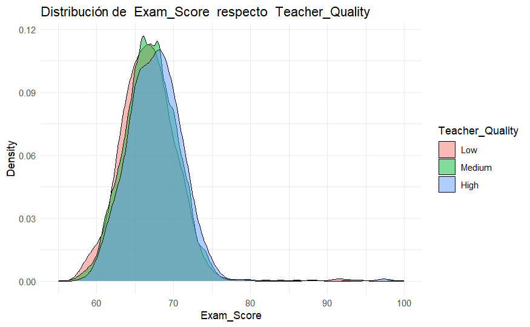

```r
density_plot_overlapped(df_recategorize, "Exam_Score", "Teacher_Quality")
```

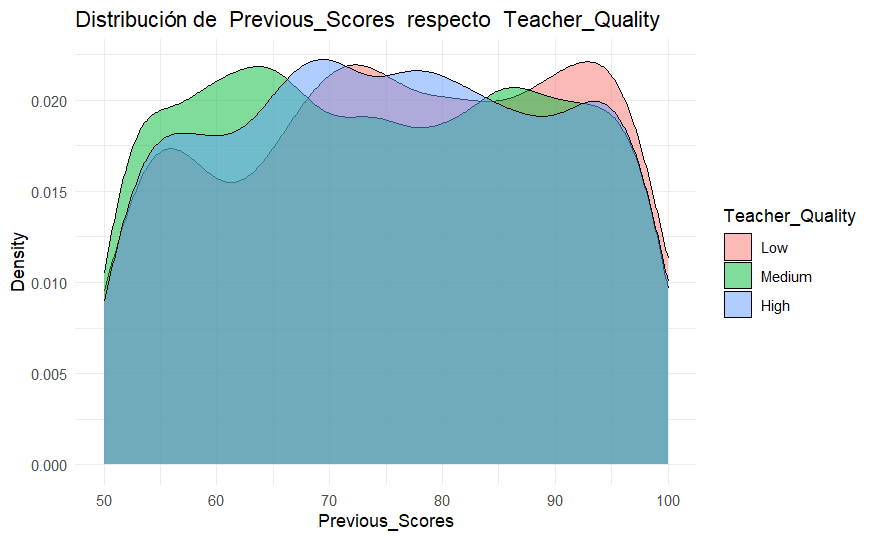

```r
density_plot_overlapped(df_recategorize, "Previous_Scores", "Teacher_Quality")
```

Respecto a **Teacher_Quality**, en `Exam_Score` la densidad de calificaciones bajas es mayor para Low Quality, mientras que para calificaciones altas es ligeramente mayor para High Quality, sugiriendo que *los profesores de alta calidad favorecen mejores resultados en los exámenes*.

En **Previous_Scores**, la *distribución es más variable*, con Medium Quality predominando en las calificaciones bajas y Low Quality en las más altas. Esto es curioso, ya que sugiere que los profesores de baja calidad, aunque asociados con calificaciones bajas, parecen influir más en los estudiantes con mejores calificaciones previas, lo que podría indicar que otros factores, como la motivación, también juegan un papel importante.

#### Relación entre Horas estudiadas y factores Institucionales

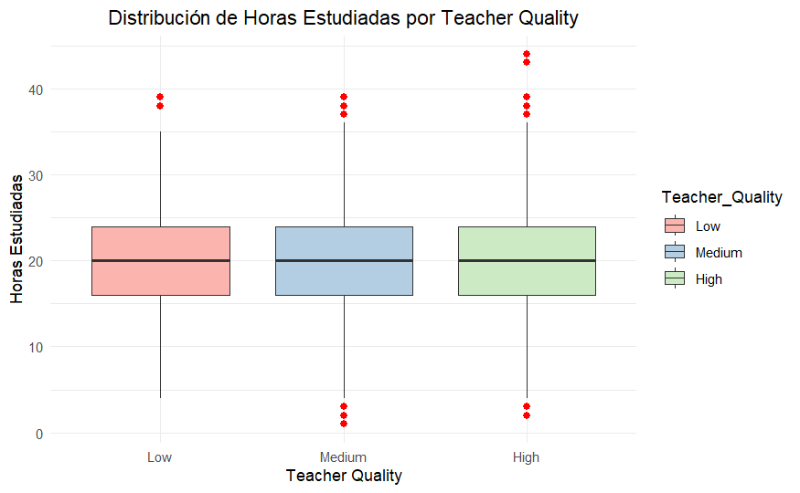

```r
boxplot_hours(df_recategorize, "Teacher_Quality")
```

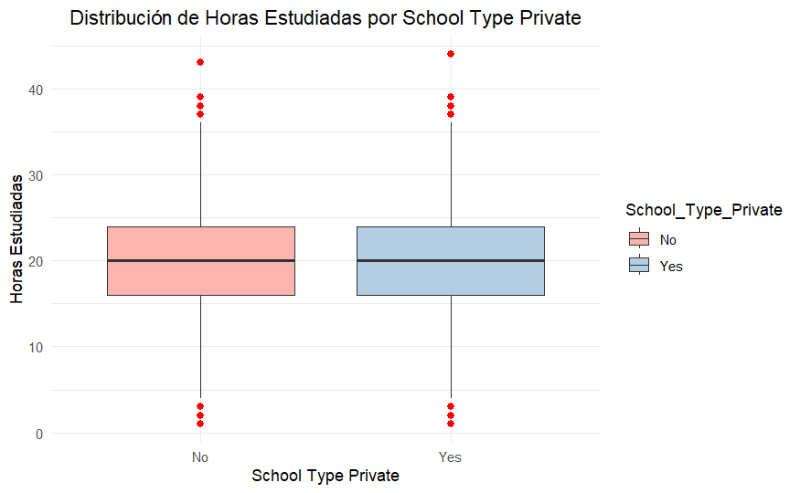

```r
boxplot_hours(df_recategorize, "School_Type_Private")
```

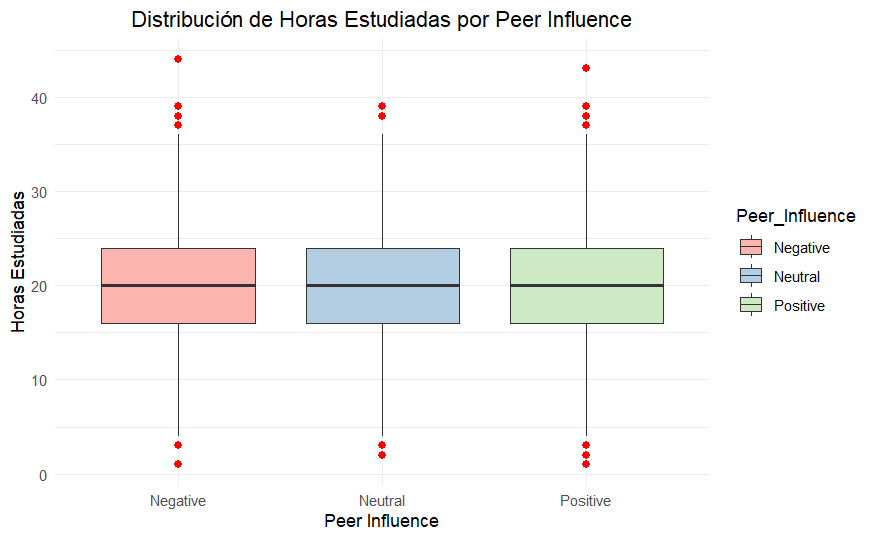

```r
boxplot_hours(df_recategorize, "Peer_Influence")
```

Al examinar los boxplots, se puede observar que *la distribución de las horas de estudio de los estudiantes es **casi idéntica para las tres variables que representan los factores institucionales*. Esto sugiere que, independientemente del factor institucional (como el tipo de escuela, la calidad docente, o la influencia de los compañeros), los estudiantes muestran un patrón similar en cuanto a la cantidad de horas dedicadas al estudio.

#### Relación entre Nivel de motivación y factores Institucionales

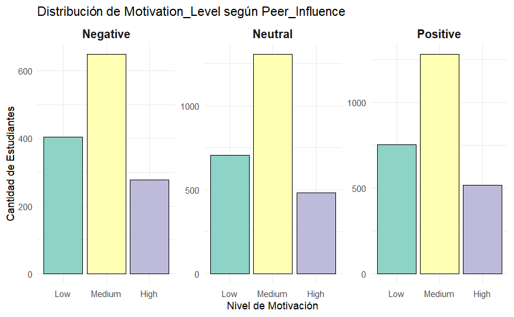

```r
grouped_bar_plot_with_facets(df_recategorize,"Peer_Influence")
```

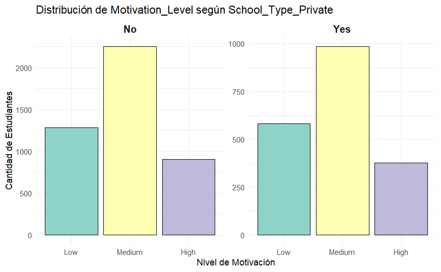

```r
grouped_bar_plot_with_facets(df_recategorize,"School_Type_Private")
```

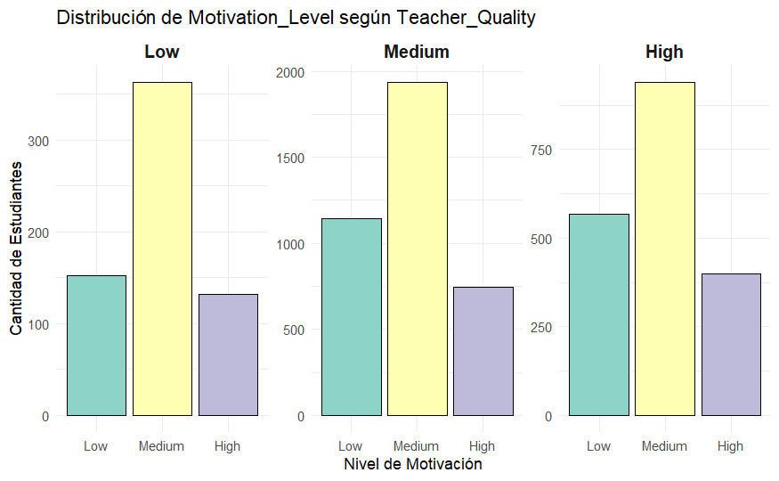

```r
grouped_bar_plot_with_facets(df_recategorize,"Teacher_Quality")
```

Respecto a los niveles de motivación de los estudiantes, se observa que las distribuciones son **prácticamente idénticas** para cada una de las categorías de todos los factores institucionales. Esto sugiere que, independientemente de las diferencias en los factores institucionales (como el tipo de escuela, la calidad docente o la influencia de los compañeros), los niveles de motivación de los estudiantes no se ven significativamente afectados por estos factores, al menos en los términos que se están analizando.

#### Conclusiones Análisis exploratorio

Una vez finalizado el análisis exploratorio vamos a resumir las principales conclusiones de este apartado:

En resumen, aunque algunos detalles puntuales fueron observados, no se detectaron impactos sustanciales de los factores institucionales en las variables analizadas.

#### Gráfico de red

Antes de comenzar con el apartado de modelado predictivo, se va a generar un **gráfico de red** con el objetivo de visualizar las relaciones entre las variables categóricas (como la calidad del profesor, tipo de escuela e influencia de los compañeros) y la calificación final (Exam_Score). Este análisis preliminar permite identificar un resumen general de las correlaciones entre las variables.

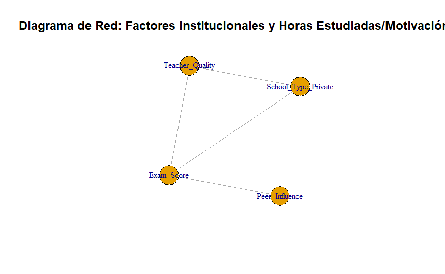

```r
# Crear una matriz de correlación entre las variables
set.seed(123)

cor_matrix <- cor(df_cleaned[, c("Exam_Score", "Teacher_Quality", "School_Type_Private", "Peer_Influence")], use = "complete.obs")

# Crear un gráfico de red a partir de la matriz de correlación
graph <- graph_from_adjacency_matrix(cor_matrix, mode = "undirected", weighted = TRUE, diag = FALSE)

# Dibuja el gráfico de red
plot(graph, vertex.size = 30, vertex.label.cex = 0.8, edge.width = E(graph)$weight * 5,
     main = "Diagrama de Red: Factores Institucionales y Horas Estudiadas/Motivación")
```

El gráfico muestra que todas las variables relacionadas con los factores institucionales, como `Teacher_Quality`, `School_Type_Private` y `Peer_Influence`, están correlacionadas con la variable objetivo **Exam_Score**, lo que refuerza la idea de que puede que el entorno escolar influye en el rendimiento académico. Además, destaca una correlación interesante entre *School_Type_Private* y *Teacher_Quality*, lo que sugiere que *las escuelas privadas podrían tener una mayor calidad de profesorado, lo que a su vez impacta en las calificaciones*. Estos hallazgos serán clave para el modelado predictivo, ya que podrían indicar relaciones indirectas entre variables que necesitan ser consideradas.

## 2.Modelado Predictivo del Rendimiento Académico

Una vez hemos realizado un análisis de las relaciones entre los factores institucionales y el desempeño estudiantil, se va a realizar un modelo de predicción para estimar la calificación final de los alumnos en función de las variables relacionadas con los factores institucionales. El objetivo es usar estas variables para predecir el rendimiento académico final de los estudiantes, representado por la variable `Exam_Score`.

### Regresión lineal múltiple

Para ello, se utilizará **regresión lineal múltiple**, que es una técnica estadística utilizada para modelar la relación entre una variable dependiente y varias variables independientes. En este caso, la **variable dependiente** será `Exam_Score` (la calificación final de los estudiantes), mientras que **las variables independientes serán los factores institucionales** como calidad del profesorado, tipo de escuela y la influencia de los compañeros.

Empleando esta técnica el objetivo es lograr identificar qué tan fuertemente cada uno de estos factores influye en el rendimiento académico, así como también proporcionará una **fórmula matemática** que podrá ser utilizada para predecir las calificaciones futuras de los estudiantes, basándose en las características de su entorno institucional.

**Especificación del modelo**

El modelo que se va a usar para la predicción de la calificación final de los estudiantes es el siguiente:

Exam_Score = B0 + B1 x `Teacher_Quality` + B2 x`School_Type_Private` + B3 x`Peer_Influence` + e

donde

- B0 es el intercepto o término constante.
- B1,…B3 son los coeficientes que indican la influencia en cada variable predictora de la calificación final.
- e es el término de error, que captura la variabilidad no explicada por las variables predictoras.

En este bloque entrenamos un modelo de regresión lineal utilizando las variables `Teacher_Quality`, `School_Type_Private` y `Peer_Influence` para predecir la variable dependiente **Exam_Score**. Luego, mostramos un resumen del modelo para observar los coeficientes y la significancia de las variables.

```r
model <- lm(Exam_Score ~ Teacher_Quality + School_Type_Private + Peer_Influence, data = df_cleaned)

# Ver el resumen del modelo
summary(model)
```

```
Call:
lm(formula = Exam_Score ~ Teacher_Quality + School_Type_Private +
    Peer_Influence, data = df_cleaned)

Residuals:
    Min      1Q  Median      3Q     Max
-11.512  -2.522  -0.114   2.365  32.488

Coefficients:
                    Estimate Std. Error t value Pr(>|t|)
(Intercept)         65.00823    0.23497 276.671  < 2e-16 ***
Teacher_Quality      0.49357    0.08090   6.101 1.12e-09 ***
School_Type_Private  0.09068    0.10563   0.858    0.391
Peer_Influence       0.51630    0.06429   8.031 1.14e-15 ***
---
Signif. codes:  0 ‘***’ 0.001 ‘**’ 0.01 ‘*’ 0.05 ‘.’ 0.1 ‘ ’ 1

Residual standard error: 3.883 on 6374 degrees of freedom
Multiple R-squared:  0.0157,    Adjusted R-squared:  0.01524
F-statistic: 33.89 on 3 and 6374 DF,  p-value: < 2.2e-16
```

A continuación, realizamos las predicciones utilizando el modelo ajustado sobre los datos de entrenamiento y calculamos las métricas de rendimiento, como el R² y el RMSE, para evaluar la capacidad predictiva del modelo.

```r
# Evaluación del modelo
# Predicciones en los datos de entrenamiento
predictions <- predict(model, df_cleaned)

# Cálculo de las métricas de rendimiento (R2 y RMSE)
actuals <- df_cleaned$Exam_Score
residuals <- actuals - predictions

# R-cuadrado (R2)
r_squared <- summary(model)$r.squared
cat("R-squared:", r_squared, "\n")
```

```
R-squared: 0.01570163
```

```r
# Error cuadrático medio (RMSE)
rmse <- sqrt(mean(residuals^2))
cat("Root Mean Squared Error (RMSE):", rmse, "\n")
```

```
Root Mean Squared Error (RMSE): 3.881739
```

Para poder observar de forma gráfica las predicciones del modelo en comparación con los valores reales de la calificación vamos a crear un **diagrama de dispersión (scatter plot)**, en el cual comparamos las predicciones generadas por el modelo con los valores reales de la calificación final.

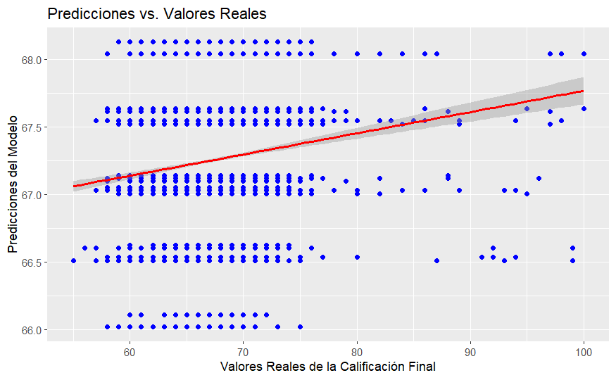

```r
# Visualizar las predicciones vs. los valores reales
ggplot(df_cleaned, aes(x = actuals, y = predictions)) +
  geom_point(color = "blue") +
  geom_smooth(method = "lm", color = "red") +
  labs(title = "Predicciones vs. Valores Reales",
       x = "Valores Reales de la Calificación Final",
       y = "Predicciones del Modelo")
```

Observamos como R2 nos da **0.0157**. Esto indica que solo el 1.57% de la variabilidad de las calificaciones finales (Exam_Score) está explicada por las variables Teacher_Quality, School_Type_Private y Peer_Influence. Esto sugiere que **el modelo no es muy bueno para predecir las calificaciones**, ya que la mayoría de la variabilidad queda sin explicar. Respecto a R2 ajustado, nos da **0.01524**, que es muy similar al R², lo que indica que el modelo tiene poco poder predictivo.

### Gradient Boosting Machines (GBM)

Viendo que los resultados obtenidos en la regresión lineal múltiple han sido pobres, se va a optar por explorar un modelo más complejo y poderoso como **Gradient Boosting Machines (GBM)**, que generalmente ofrece una mayor capacidad predictiva al construir modelos basados en árboles de decisión de manera iterativa.

De este modo, una vez realizado el proceso podremos comparar los resultados obtenidos con los del modelo de regresión lineal para ver si hay una mejora en el rendimiento.

El primer paso es ajustar el modelo de Gradient Boosting Machine (GBM). Para ello vamos a realizar **validación cruzada (Cross Validation)** con k = 10, lo que ayuda a garantizar que el modelo sea robusto y no se sobreajuste a los datos. También se va a mostrar la importancia de las variables utilizadas en el modelo que en nuestro caso son aquellas correspondientes a los factores institucionales (`Teacher_Quality`, `Peer_Influence` y `School_Type_Private`).

Esto nos va a proporcionar información sobre el impacto de cada variable en la predicción de la calificación final (Exam_Score) de un modo más claro a como se nos proporcionaba en la regresión múltiple.

|  | var | rel.inf |
| --- | --- | --- |
| Peer_Influence | Peer_Influence | 57.099500 |
| Teacher_Quality | Teacher_Quality | 38.014074 |
| School_Type_Private | School_Type_Private | 4.886426 |

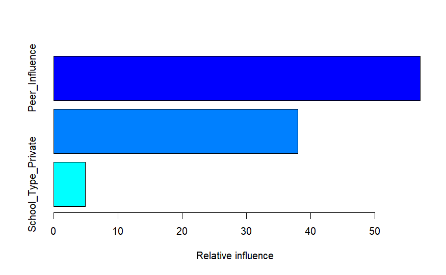

```r
train_control <- trainControl(method = "cv", number = 10)

gbm_model <- train(Exam_Score ~ Teacher_Quality + School_Type_Private + Peer_Influence,
                   data = df_cleaned,
                   method = "gbm",
                   trControl = train_control,
                   verbose = FALSE)

summary(gbm_model)
```

Una vez hemos realizado el ajuste del modelo, vamos a realizar las predicciones sobre los datos y al igual que en el apartado de regresión multiple se van a calcular métricas como RMSE y el R² para evaluar la calidad del modelo.

```r
# Predicciones en el conjunto de datos
gbm_predictions <- predict(gbm_model, df_cleaned)

# Calcular el error cuadrático medio (RMSE)
gbm_residuals <- df_cleaned$Exam_Score - gbm_predictions
gbm_rmse <- sqrt(mean(gbm_residuals^2))
cat("RMSE del modelo GBM:", gbm_rmse, "\n")
```

```
RMSE del modelo GBM: 3.881426
```

```r
# Calcular R-cuadrado (R²)
gbm_r_squared <- 1 - sum(gbm_residuals^2) / sum((mean(df_cleaned$Exam_Score) - df_cleaned$Exam_Score)^2)
cat("R-cuadrado del modelo GBM:", gbm_r_squared, "\n")
```

```
R-cuadrado del modelo GBM: 0.01586044
```

Por último, vamos a generar un **Lollipop plot** que muestra la **importancia de los factores institucionales** que han sido utilizados como variables en el modelo Gradient Boosting Machine (GBM).

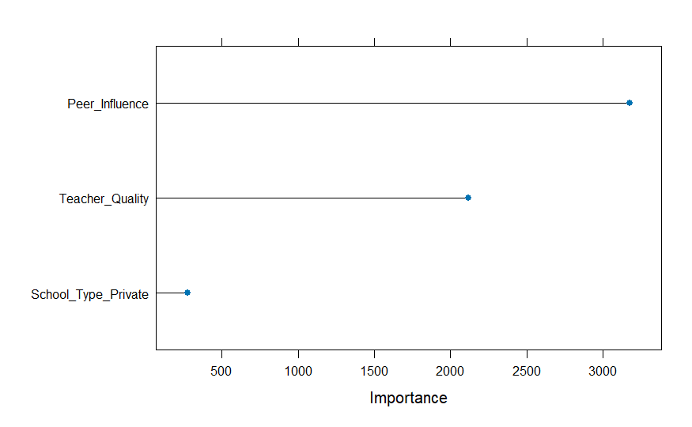

```r
# Importancia de las variables
var_imp <- varImp(gbm_model, scale = FALSE)

# Visualizar la importancia de las variables
plot(var_imp)
```

### Conclusiones generales

En resumen, estas conclusiones nos sugieren que existen **otros factores** más allá de los institucionales que podrían influir de manera significativa en el rendimiento académico de los estudiantes. Es probable que aspectos personales y sociales, como la motivación individual, el apoyo familiar o las estrategias de estudio utilizadas por cada estudiante, jueguen un papel mucho más determinante en el rendimiento académico de los estudiantes.

#PREGUNTA 2. Análisis de Patrones en la Actividad Física de Estudiantes mediante Reglas de Asociación

El equilibrio entre estudio y actividad física es fundamental para el rendimiento académico y la salud de los estudiantes. Diversos estudios han demostrado que el ejercicio contribuye a mejorar la concentración, reducir el estrés y aumentar el bienestar emocional. Un ejemplo es el estudio realizado por la **Universidad de Jaén**, publicado en la Revista INFAD de Psicología, que encontró una *relación positiva entre la actividad física moderada a vigorosa y el desempeño académico en educación física*, aunque no en otras materias. Sin embargo, en un mundo donde la competencia académica es cada vez mayor, muchos estudiantes podrían estar *priorizando el estudio en detrimento de su salud física*. Por ejemplo, en mi caso personal, tuve que abandonar practicar fútbol para enfocarme en mis estudios de bachillerato para así obtener mejores calificaciones.

Este estudio busca analizar la relación entre el tiempo dedicado al estudio y la actividad física en estudiantes, considerando factores como la asistencia a clases, la participación en actividades extraescolares, el género y la distancia de casa a la escuela. La pregunta clave es si los estudiantes que más estudian o tienen mayor compromiso académico sacrifican su tiempo de ejercicio físico, lo que podría afectar su bienestar general.

Para ello, se van a responder a las siguientes preguntas:

- **¿Qué factores son aquellos que afectan más en la cantidad de ejercicio físico realizado por el estudiante?**
- **¿Existe una correlación entre el rendimiento académico y la cantidad de actividad física realizada?**
- **¿El género o la distancia de la escuela a casa juegan un papel importante en el equilibrio entre el estudio y la actividad física?**

Para abordar esta serie de cuestiones, se aplicarán diversas técnicas de análisis de datos. En primer lugar, se utilizarán gráficos descriptivos, como boxplots, para observar la distribución de la actividad física en función de diferentes factores categóricos. Posteriormente, se emplearán técnicas de modelado predictivo para investigar este apartado más a fondo.

En particular, se utilizarán **reglas de asociación** para identificar patrones en los datos entre las variables categóricas y el tiempo de actividad física. Esta técnica permitirán estudiar no solo las relaciones directas, sino también las interacciones entre diferentes factores que podrían afectar el comportamiento de los estudiantes respecto a su actividad física.

### Análisis exploratorio

#### Distribución de horas de ejercicio físico

Lo primero es comenzar con un análisis básico de la distribución de la variable objetivo `Physical_Activity`, que representa el número medio de horas de actividad física que realiza un estudiante por semana.

```r
summary(data$Physical_Activity)
```

```
   Min. 1st Qu.  Median    Mean 3rd Qu.    Max.
  0.000   2.000   3.000   2.973   4.000   6.000
```

El resumen estadístico de la variable `Physical_Activity` muestra que la mayoría de los estudiantes realiza una **cantidad moderada de actividad física**, con una media de aproximadamente *2.97 horas por semana y una mediana de 3 horas*. La distribución de los datos sugiere que **el 75% de los estudiantes realiza 4 horas o menos de ejercicio físico**, con un **máximo de 6 horas semanales**. Esto indica que, en general, *los estudiantes no dedican muchas horas a la actividad física, lo que podría estar relacionado con la carga académica u otras responsabilidades*.

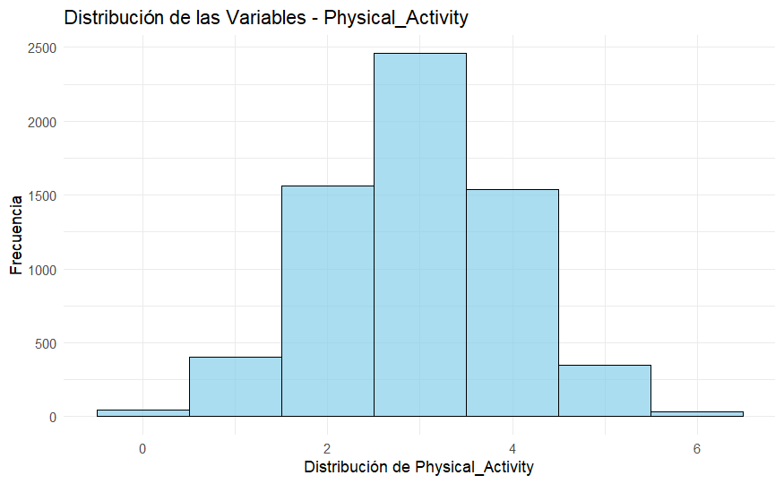

```r
create_histograms <- function(data, variables, binwidth = 1, fill_color = "skyblue", title = "Distribución de las Variables") {
  for (var in variables) {
    p <- ggplot(data, aes_string(x = var)) +
      geom_histogram(binwidth = binwidth, fill = fill_color, color = "black", alpha = 0.7) +
      labs(title = paste(title, "-", var),
           x = paste("Distribución de", var),
           y = "Frecuencia") +
      theme_minimal()

    print(p)
  }
}


create_histograms(data,"Physical_Activity")
```

Observando el histograma, se puede apreciar que las horas de actividad física semanales siguen una distribución normal, con una concentración de datos en torno a un valor central y una caída progresiva hacia los extremos donde observamos que la gran mayoría de alumnos se encuentran en torno a las **3 Horas semanales de ejercicio físico**.

#### Distribución de variables académicas

Debido a que posteriormente debemos realizar una categorización de las variables para dividirlas en rangos antes de realizar las reglas de asociación va a ser necesario visualizar la **distribución de variables académicas**. Esto va a ayudar a definir los puntos de corte más apropiados para las categorías que vamos a crear.

```r
academic_vars <- c("Previous_Scores", "Exam_Score", "Attendance", "Hours_Studied", "Tutoring_Sessions")
```

```r
summary_academic_vars <- function(data, vars) {
  summary_data <- data[, vars]
  summary(summary_data)
}

summary_academic_vars(data, academic_vars)
```

```
 Previous_Scores    Exam_Score       Attendance     Hours_Studied   Tutoring_Sessions
 Min.   : 50.00   Min.   : 55.00   Min.   : 60.00   Min.   : 1.00   Min.   :0.000
 1st Qu.: 63.00   1st Qu.: 65.00   1st Qu.: 70.00   1st Qu.:16.00   1st Qu.:1.000
 Median : 75.00   Median : 67.00   Median : 80.00   Median :20.00   Median :1.000
 Mean   : 75.07   Mean   : 67.25   Mean   : 80.02   Mean   :19.98   Mean   :1.495
 3rd Qu.: 88.00   3rd Qu.: 69.00   3rd Qu.: 90.00   3rd Qu.:24.00   3rd Qu.:2.000
 Max.   :100.00   Max.   :100.00   Max.   :100.00   Max.   :44.00   Max.   :8.000
```

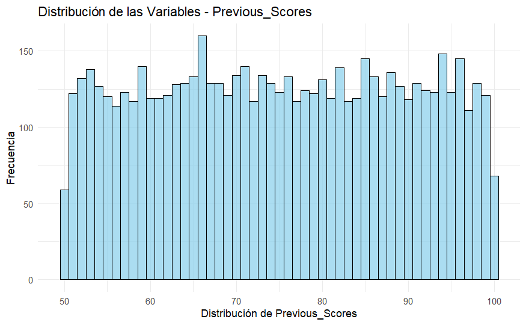

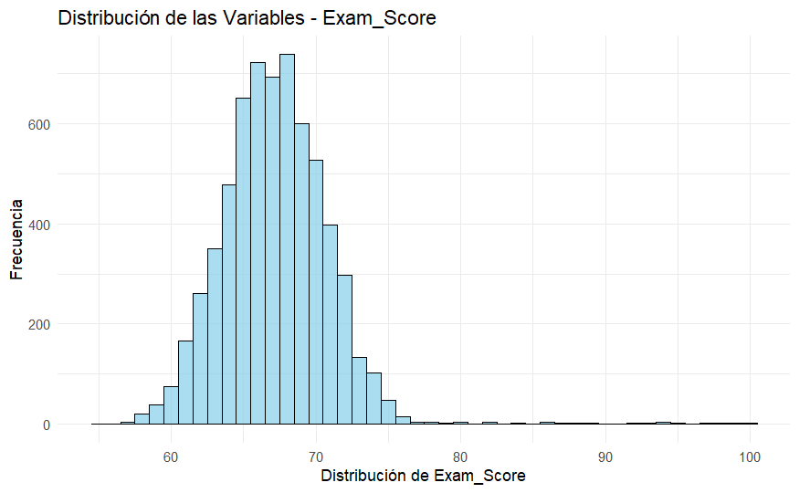

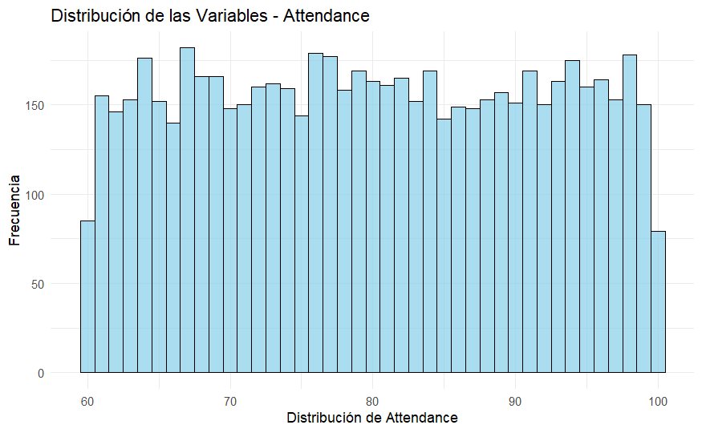

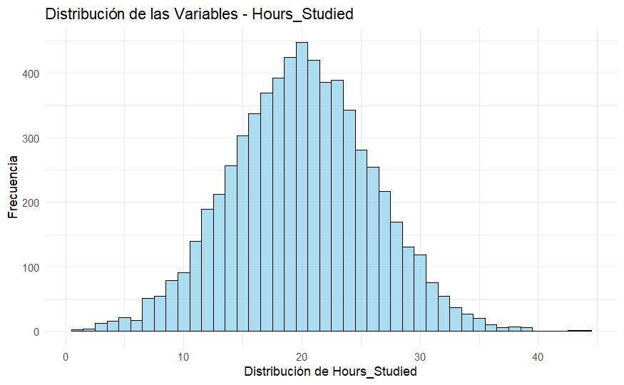

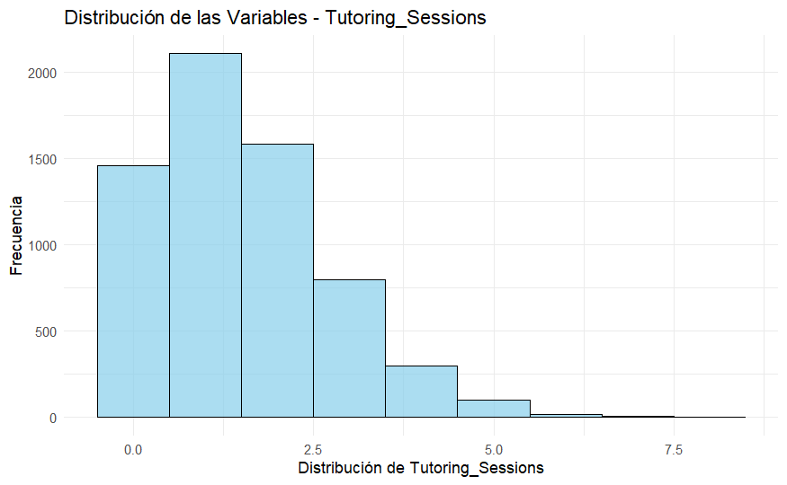

```r
create_histograms(data, academic_vars)
```

A partir tanto de la información de summary como de la distribución de cada una de las variables académicas vamos a realizar la posterior codificación de los datos de este modo:

- `Exam_Score` y `Previous_Score`: El rango de calificaciones va de 0 a 100. Por lo que podremos seguir el método de agrupación de calificaciones seguido en España donde entre 5 y 5.9 es aprobado, entre 6 y 6.9 es Bien, entre 7 y 8.9 es notable y entre 9 y 10 es sobresaliente.
- `Attendance`: El mínimo es 60 y dado que la mayoría de los estudiantes parecen tener un 80% de asistencia en promedio, podría ser más apropiado ajustar los límites: **Baja** (Menos de 60%), **Media** (De 60% a 75%) y **Alta** (75% o más).
- `Hours_Studied`: Vamos a ajustarlo a 5 rangos específicos: **Pocas horas (0 - 5 horas)**, **Horas moderadas (6-15)**, **Horas razonables (16-30 horas)**, **Horas excesivas (31-40 horas)** y **excesivas (Más de 40 horas)**.
- `Tutoring_Sessions`: Vamos a ajustarlo a 3 rangos donde los que tengan 0 de horas de tutoria serán **Sin tutoria**, entre 1 y 3 serán **Pocas tutorias** y mayor a 3 serán **muchas tutorias**.

### Relaciones entre variables académicas

A continuación, exploraremos las relaciones entre la actividad física de los estudiantes y las diversas variables académicas tanto numericas como las categorizadas. Para esto, utilizaremos técnicas de visualización y análisis descriptivo, buscando posibles patrones o tendencias que puedan ser relevantes para responder a las preguntas planteadas que servirán como análisis previo a las reglas de asociación.

#### Relación entre actividad física y calificaciones junto con asistencia

Una de las principales cuestiones que se busca analizar en este estudio es si existe alguna correlación o relación entre el rendimiento académico y la cantidad de actividad física realizada. Para esto se va a hacer uso de **diagramas de dispersión** para observar cómo se distribuye la actividad física en relación con las categorías de rendimiento académico (como `Exam_Score` y `Previous_Scores`).

```r
create_scatter_plot <- function(df, var_x, var_y) {
  ggplot(df, aes_string(x = var_x, y = var_y, color = var_y)) +
    geom_point(alpha = 0.7, size = 3) +
    geom_smooth(method = "lm", color = "black", se = FALSE) +
    scale_color_viridis_c(option = "magma") +
    labs(title = paste("Relación entre", var_x, "y", var_y),
         x = var_x, y = var_y, color = var_y) +
    theme_minimal()
}
```

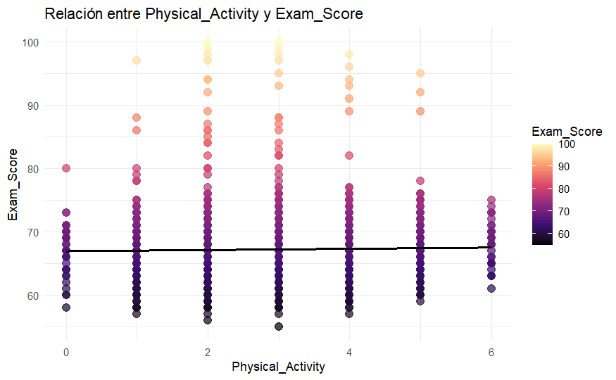

```r
create_scatter_plot(data, "Physical_Activity", "Exam_Score")
```

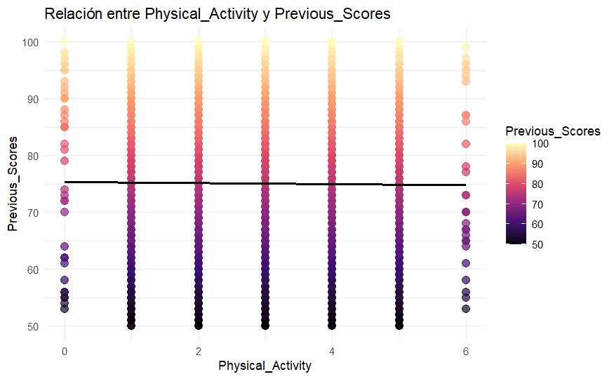

```r
create_scatter_plot(data, "Physical_Activity", "Previous_Scores")
```

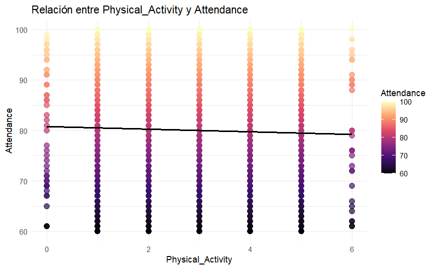

```r
create_scatter_plot(data, "Physical_Activity", "Attendance")
```

Observamos que la distribución de calificaciones para calificaciones (`Exam_Score` y `Previous_Scores`) como para asistencia (`Attendance`) es similar para cada una de las horas de actividad física realizadas por los estudiantes, notamos que estas distribuciones son bastante similares entre los diferentes grupos de horas de actividad física. Es decir, al encontrarse una distribución tan amplia de calificaciones y asistencia en cada una de las horas de actividad física no se permiten observar diferencias significativas.